# Plotting time series

# Apollo data

In these exercises, we will use the [Apollo time use dataset](http://www.apollochoicemodelling.com/files/apollo_timeUseData_dictionary.pdf) (slightly modified for our purposes), which has 2,826 observations from 447 participants. This time series has records of daily time spent (in minutes) on various activities, such as working, shopping, or travelling (variables starting with “t_a”; see the link above for description). Other variables include participant ID, date, age, and dummy variables for gender (1 = female, 0 = male) and work status (1 = full time, 0 = other).

```r
glimpse(timeuse)
```

```
Rows: 2,826
Columns: 17
$ indivID       <dbl> 19209, 19209, 19209, 19209,...
$ date          <dbl> 20170124, 20170125, 2017012...
$ t_a01         <dbl> 39, 23, 0, 89, 727, 346, 98...
$ t_a02         <dbl> 0, 0, 0, 0, 0, 511, 0, 348,...
$ t_a03         <dbl> 0, 0, 0, 0, 0, 0, 0, 0, 0, ...
$ t_a04         <dbl> 54, 0, 140, 43, 112, 0, 4, ...
$ t_a05         <dbl> 4, 0, 0, 0, 0, 0, 25, 9, 0,...
$ t_a06         <dbl> 0, 0, 0, 1, 0, 0, 0, 0, 0, ...
$ t_a07         <dbl> 0, 0, 0, 164, 0, 0, 57, 0, ...
$ t_a08         <dbl> 0, 0, 0, 0, 0, 0, 0, 0, 0, ...
$ t_a09         <dbl> 71, 75, 0, 88, 0, 0, 0, 0, ...
$ t_a10         <dbl> 1189, 1254, 1278, 930, 560,...
$ t_a11         <dbl> 83, 88, 22, 125, 41, 118, 2...
$ t_a12         <dbl> 0, 0, 0, 0, 0, 0, 0, 0, 0, ...
$ female        <dbl> 1, 1, 1, 1, 1, 0, 0, 0, 0, ...
$ age           <dbl> 34.5, 34.5, 34.5, 34.5, 34....
$ occ_full_time <dbl> 0, 0, 0, 0, 0, 1, 1, 1, 1, ...
```

First, let’s take care of the column types and then convert to longer format. We will also subset the data to contain the year 2016 only, and assign the tidied dataset to **tidytime**.

#### Working with dates in lubridate

Values can be turned into dates (or datetimes) easily with functions such as ymd(), dmy(), mdy(), or ymd_hms(), dmy_hms(), where y = year, m = month, d = day (and h = hours, m = minutes, s = seconds).

Let’s also recode the activity variable to have more informative values.

(!!! is used to *evaluate a list of expressions* - sounds tricky but here you can think of it as “unwrapping” the vector of recoding keys)

| indivID | date | female | age | occ_full_time | activity_class | time_spent |
| --- | --- | --- | --- | --- | --- | --- |
| 1013302 | 2016-11-11 | 0 | 70.0 | 0 | lifts | 0 |
| 1013302 | 2016-11-11 | 0 | 70.0 | 0 | work | 0 |
| 1013302 | 2016-11-11 | 0 | 70.0 | 0 | education | 0 |
| 1013302 | 2016-11-11 | 0 | 70.0 | 0 | shopping | 0 |
| 1013302 | 2016-11-11 | 0 | 70.0 | 0 | business | 0 |
| 1013302 | 2016-11-11 | 0 | 70.0 | 0 | petrol | 0 |
| 1013302 | 2016-11-11 | 0 | 70.0 | 0 | social / leisure | 0 |
| 1013302 | 2016-11-11 | 0 | 70.0 | 0 | vacation | 0 |
| 1013302 | 2016-11-11 | 0 | 70.0 | 0 | exercise | 6 |
| 1013302 | 2016-11-11 | 0 | 70.0 | 0 | home | 1424 |

[output cut: 990 more lines]

#### Aggregating multilevel data

Let’s summarise the data frame **from a participant-level time series to an aggregated time series** (mean time spent per activity per day).

| date | activity_class | time_spent | n |
| --- | --- | --- | --- |
| 2016-10-14 | business | 0.000000e+00 | 6 |
| 2016-10-14 | education | 0.000000e+00 | 6 |
| 2016-10-14 | exercise | 2.281667e+02 | 6 |
| 2016-10-14 | home | 9.640000e+02 | 6 |
| 2016-10-14 | lifts | 0.000000e+00 | 6 |
| 2016-10-14 | non-allocated | 0.000000e+00 | 6 |
| 2016-10-14 | petrol | 0.000000e+00 | 6 |
| 2016-10-14 | shopping | 2.333333e+00 | 6 |
| 2016-10-14 | social / leisure | 8.483333e+01 | 6 |
| 2016-10-14 | travel | 3.816667e+01 | 6 |

[output cut: 866 more lines]

Now we can plot the average time spent in each activity type as a time series.

Note how the date labels are modified with **scale_x_date**!

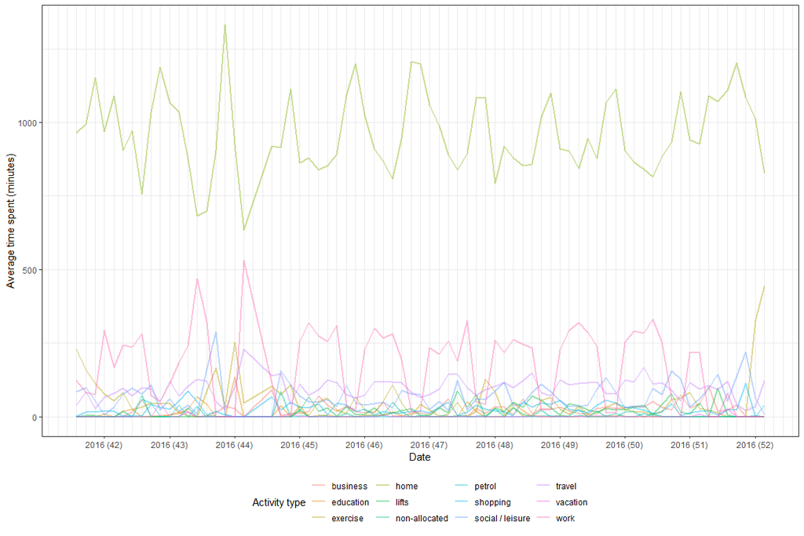

There seems to be some periodicity in the data. Let’s have a look at the data on a weekly basis. We’ll use weekday (Mon-Sun) on the x-axis and make subplots for activity types, plotting weeks as separate lines. Before that, let’s make a few more modifications.

**Weekday** is computed with the `wday()` function, which returns the number (`label = F`) or name (`label = T`; ordered factor) of the weekday. The week starts by default on Sunday, but we’re setting it to start on Monday with week_start = 1.

**Week number** is computed by simply extracting the week from date with `week(date)`.

We modify the **activity classes** to start with uppercase letters (`str_to_title()`), and move the “non-allocated” category to the last level (see where it is in the plot).

```r
tidytime_agg <- tidytime_agg %>%
  mutate(weekday = wday(date, label = T, abbr = T, week_start = 1, locale = "English"),
         week_number = week(date)) %>%
  mutate(activity_class = str_to_title(activity_class), # modify activity class
         activity_class = fct_relevel(activity_class, "Non-Allocated", after = Inf)) # move "non-allocated" to last place

tidytime_agg
```

#### Recoding with if_else and case_when

Let’s create a **weekend** variable denoting whether the date is in a weekend. This can be done in multiple ways; here, we’ll go through `if_else()` and `case_when()`. Since if_else only has room for one condition, it can be used with simple recoding. On the other hand, case_when can handle multiple conditions and values (note that it is order-dependent; the conditions should be listed from the most specific to the most general). In fact, case_when is like using successive if_else statements.

```r
# method 1: if_else
tidytime_agg %>%
  mutate(is_weekend = if_else(weekday %in% c("Sat", "Sun"), 1, 0)) # if_else(condition, true values, false values)

# method 2: case_when
tidytime_agg %>%
  mutate(is_weekend = case_when(weekday %in% c("Sat", "Sun") ~ 1, # case_when(condition1 ~ true value, ...)
                                weekday %in% c("Mon", "Tue", "Wed", "Thu") ~ 0, # note that Fri is not listed
                                TRUE ~ 0)) # this means "in all other cases: is_weekend = 0"
# or, in this case, shorter:
tidytime_agg %>%
  mutate(is_weekend = case_when(weekday %in% c("Sat", "Sun") ~ 1,
                                TRUE ~ 0))  %>%
  mutate(is_weekend = factor(is_weekend))
```

#### Time spent on activities per weekday

**Some adjustments to the figure**:

- Because the scale of time spent varies greatly between activities, we set individual y-axis scales for the subplots (see the difference if you remove it!)
- We will use the same colour coding as in the above plot, but since the activity classes are shown as facet labels, we can remove the colour legend

```r
tidytime_agg %>%
  ggplot(aes(weekday, time_spent, color = activity_class, group = week_number)) +
  geom_line(size=1, alpha = .1) +
  geom_point(alpha = .6) +
  facet_wrap(~activity_class, scales = "free_y") + # let y-axis scale vary between facets
  labs(x = "Weekday", y = "Average time spent (minutes)", colour = "Activity type") +
  theme_bw() +
  theme(legend.position = "none") # remove the legend
```

[output not shown]

We can also aggregate the weeks together to get **average time spent on an activity broken down by weekday**. How exactly should this be calculated?

(Function `plot_grid()` from the cowplot package is used to print plots side-by-side.)

```r
tidytime <- tidytime %>%
  mutate(weekday = wday(date, label = T, abbr = T, week_start = 1, locale = "English"),
         week_number = week(date)) %>%
  mutate(activity_class = str_to_title(activity_class), # modify activity class
         activity_class = fct_relevel(activity_class, "Non-Allocated", after = Inf))

fig1 <- tidytime %>% # start with "raw" data
  group_by(weekday, activity_class) %>%
  summarise(time_spent = mean(time_spent)) %>%
  ungroup %>%
  ggplot(aes(weekday, time_spent, color = activity_class, group=1)) + geom_line(size=1) +
  facet_wrap(~activity_class, scales = "free_y") +
  labs(x = "Weekday", y = "Average time spent (minutes)", colour = "Activity type", title = "Figure 1",
       subtitle = "Mean calculated from all values") + theme_bw() +
  theme(legend.position = "none")


fig2 <- tidytime_agg %>% # start with aggregated data
  group_by(weekday, activity_class) %>%
  summarise(time_spent = mean(time_spent)) %>%
  ungroup %>%
  ggplot(aes(weekday, time_spent, color = activity_class, group=1)) + geom_line(size=1) +
  facet_wrap(~activity_class, scales = "free_y") +
  labs(x = "Weekday", y = "Average time spent (minutes)", colour = "Activity type", title = "Figure 2",
       subtitle = "Mean calculated from daily means") + theme_bw() +
  theme(legend.position = "none")

cowplot::plot_grid(fig1, fig2, ncol = 1)
```

[output not shown]

This is illustrated in the below example.

```r
day1_small <- c(100, 10) # n = 2 with "outlier"
day2 <- c(10, 14, 18, 14, 20) # n = 5

paste("Mean of all values (small sample with outlier):", mean(c(day1_small, day2)) %>% round(1)) # smaller

mean_day1_small = mean(day1_small) # outlier affects day-wise mean
mean_day2 = mean(day2)

paste("Mean of daily means (small sample with outlier):", mean(c(mean_day1_small, mean_day2)) %>% round(1)) # greater

day1 <- c(100, 12, 15, 13, 16) # n = 5 with "outlier"
day2 <- c(10, 14, 18, 14, 20) # n = 5

paste("Mean of all values (balanced samples with outlier):", mean(c(day1, day2)) %>% round(1))

mean_day1 = mean(day1)
mean_day2 = mean(day2)

paste("Mean of daily means (balanced samples with outlier):", mean(c(mean_day1, mean_day2)) %>% round(1))
```

[output not shown]

#### Visualising skewed data

```r
tidytime %>%
  ggplot(aes(time_spent)) + geom_density() +
  labs(x = "Time spent (minutes)", title = "Distribution of all records") +
  theme_bw()

tidytime_agg %>%
  ggplot(aes(time_spent)) + geom_density() +
  labs(x = "Time spent (minutes)", title = "Distribution of daily averages") +
  theme_bw()

# let's make aggregates based on median
tidytime_agg_md <- tidytime %>%
  group_by(date, activity_class) %>%
  summarise(time_spent = median(time_spent), # create a variable of the same name
            n = n()) %>%
  ungroup() %>%
  mutate(weekday = wday(date, label = T, abbr = T, week_start = 1, locale = "English"),
         week_number = week(date)) %>%
  mutate(activity_class = str_to_title(activity_class),
         activity_class = fct_relevel(activity_class, "Non-Allocated", after = Inf))

tidytime_agg_md %>%
  ggplot(aes(time_spent)) + geom_density() +
  labs(x = "Time spent (minutes)", title = "Distribution of daily medians") +
  theme_bw()
```

[output not shown]

Let’s plot median times spent per weekday:

```r
tidytime %>%
  group_by(weekday, activity_class) %>%
  summarise(time_spent = median(time_spent)) %>%
  ungroup %>%
  ggplot(aes(weekday, time_spent, color = activity_class, group=1)) + geom_line(size=1) +
  facet_wrap(~activity_class, scales = "free_y") +
  labs(x = "Weekday", y = "Median time spent (minutes)", colour = "Activity type") + theme_bw() +
  theme(legend.position = "none")
```

[output not shown]

And it’s even better to show the whole distribution:

```r
tidytime %>%
  ggplot(aes(weekday, time_spent, color = activity_class)) +
  geom_violin() +
  stat_summary(aes(group=1), geom = "line", fun = "median", size = 1) +
  stat_summary(aes(group=1), geom = "line", fun = "mean", colour = "black", alpha = .7) +
  facet_wrap(~activity_class, scales = "free_y") +
  labs(x = "Weekday", y = "Median time spent (minutes)", colour = "Activity type") + theme_bw() +
  theme(legend.position = "none")
```

[output not shown]

#### Human time

There is another common caveat in human-reported times. Let’s remove full hours from the time_spent variable to get the remaining minutes (e.g. 1424 min -> 23 hours 44 min). Then, we calculate frequencies of the minutes and plot them.

```r
highlight_times <- seq(5, 60, by = 5)

tidytime %>%
  mutate(hours_spent = hour(seconds_to_period(time_spent*60)),
         minutes = minute(seconds_to_period(time_spent*60))) %>%
  count(minutes) %>%
  filter(minutes > 0) %>%
  mutate(highlight_count = if_else(minutes %in% highlight_times, n, NA_integer_)) %>% # if highlighted, value = count
  ggplot(aes(minutes, n)) + # grey bars
  geom_col() +
  geom_col(aes(minutes, highlight_count, fill = "Peaks")) + # when would you put fill outside aesthetics?
  geom_smooth(aes(color = "Regression line"), se=F, method = "lm")  +
  scale_color_manual(name = "", values = c("Regression line" = "black")) +
  scale_fill_manual(name = "", values = c("Peaks" = "darkred")) +
  scale_x_continuous(breaks = highlight_times) +
  geom_text(aes(label = highlight_count), vjust=-0.25) + # vjust: vertical adjustment to avoid overlap with bars
  theme_bw() +
  labs(x = "Minutes", y = "Count", title = "Distribution of minutes in self-reports")
```

[output not shown]